# Límites, Derivadas e Integrales usando Lenguaje simbólico en R

### `Ryacas`

El siguiente apunte es un resumen de la clase del sábado 14 de abril. Lo que quise fue responder la pregunta: cómo puede implementarse lo conversado en `R`. Como la materia es fundamentalmente teórica, se necesita un lenguaje de programación que pueda operar matemáticas de manera simbólica.  
En `R`, se me ocurren tres formas de hacer esto. La primera es llamando desde `R` al lenguaje `yacas`, que es la forma como lo haré. La segunda es llamando a una libreria de `Python` hacia `R` conocida como SymPy. La tercera es llamando a alguna libreria de `matlab`.  
Para usar `yacas` desde `R` se necesita el paquete `Ryacas`. Por lo tanto, lo primero es instalar y llamarlo.

```r
library(Ryacas)
```

Ryacas necesita a su vez de un paquete llamado `XML` que al parecer está en desuso, por lo que las nuevas versiones de `R` (desde 3.4.1) arrojan un mensaje de advertencia incómodo cuando lo usamos. Para cancelar de manera momentanea las advertencias, cambiamos la opción del Global Enviroment.

```r
options(warn = -1)
```

## Desafío 1.

Demuestre que:  
$\displaystyle \lim_{x\to2} \frac {x^2+5}{x-3} = -9$

```r
x <- Sym("x") #definimos x simbolicamente
```

Luego, sabemos que límite de una suma es la suma de los límites, que el límite de una constante es la constante y que el límite de una multiplicación es la multiplicación de los límites y entonces:

```r
Limit(x^2,x,2)
```

```
## expression(4)
```

```r
Limit(5,x,2)
```

```
## expression(5)
```

```r
Limit(x,x,2)
```

```
## expression(2)
```

```r
Limit(-3,x,2)
```

```
## expression(-3)
```

```r
Limit(x^2,x,2)+Limit(5,x,2)
```

```
## expression(9)
```

```r
Limit(x,x,2)-(Limit(3,x,2))
```

```
## expression(-1)
```

```r
(Limit(x^2,x,2)+Limit(5,x,2))/(Limit(x,x,2)-(Limit(3,x,2)))
```

```
## expression(-9)
```

## Desafío 2.

Grafique y calcule las asintotas de la función $\displaystyle f(x)= \frac{9x^2}{x^2+3}$

### Parte I. Graficar

Para graficar, voy a ocupar el paquete `base::graphics` que viene instalado por default y no es necesario llamar. El código sería:

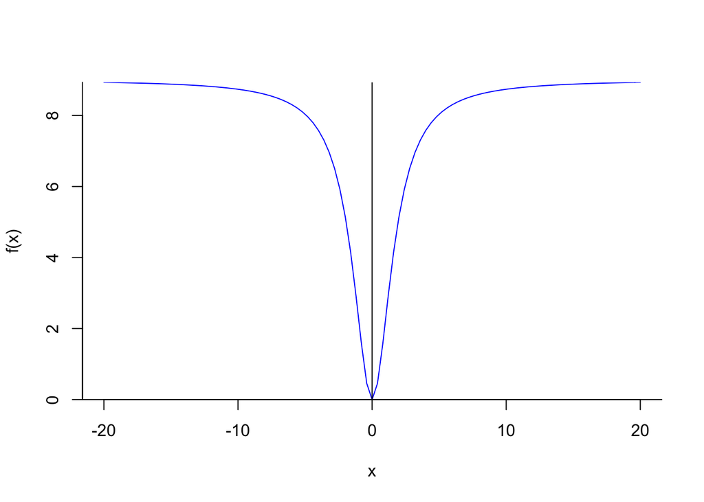

```r
curve(9*x^2/(x^2+3), from = -20, to = 20, col = "blue",
      ylab = "f(x)", bty = "L", yaxs = "i")
abline(v = 0) #grafica la funcion
```

### Parte 2. Calcule las asíntontas

Lo que demostró este ejercicio es que se necesita la regla de L’Hopital para poder determinar el límite

$$\lim_{x\to\infty} \frac {f(x)}{g(x)} = \lim_{x\to\infty} \frac {f^\prime(x)}{g^\prime(x)}$$

El código que se necesita para computar el límite en R, usando yacas es:

```r
Limit((9*x^2)/(x^2+3), x, Infinity) #calculamos el limite
```

```
## expression(9)
```

Se puede calcular usando L`Hopital:

```r
deriv1 <- deriv((9*x^2),x); deriv1 #derivadas
```

```
## expression(18 * x)
```

```r
deriv2 <- deriv((x^2+3), x); deriv2
```

```
## expression(2 * x)
```

```r
deriv <- Simplify(deriv1/deriv2); deriv #simplificamos
```

```
## expression(9)
```

```r
asintota <- yacas(Limit((9*x^2)/(x^2+3), x, Infinity), retclass = "character")
#rescatamos el valor
asintota <- as.numeric(asintota[[1]])
```

El límite de las asintotas es 9. Podemos graficarlo:

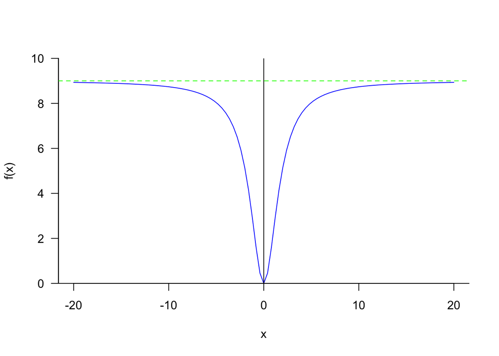

```r
curve(9*x^2/(x^2+3), from =  -20, to = 20, ylab = "f(x)", col = "blue",
      bty = "L", las = 1, yaxs = "i", ylim = c(0,10))
abline(v = 0)
abline(h = asintota, col="green", lty=2) #limite de las asintotas
```

## Desafío 3.

Grafique y calcule la derivada de la función $\displaystyle f(x)= \frac{9x^2}{x^2+3}$.

Para calcular la derivada se necesita saber que la derivada de un cuociente se puede desarrollar como:
$$\displaystyle f(x)={\frac {g(x)}{h(x)}}$$
,
$$\displaystyle {\frac {d}{dx}}f(x)=f'(x)={\frac {g'(x)h(x)-g(x)h'(x)}{{h(x)}^{2}}}$$

### Parte 1. Cálculo

```r
derivada <- deriv(9*x^2/(x^2+3),x); derivada
```

```
## expression(((x^2 + 3) * (18 * x) - 9 * (x^2 * (2 * x)))/(x^2 +
##     3)^2)
```

```r
simple <-Simplify(derivada); simple
```

```
## expression(54 * x/(x^4 + 6 * x^2 + 9))
```

La derivada es $\displaystyle \frac{(x^2 + 3) * (18 * x) - 9 * (x^2 * (2 * x))}{(x^2+3)^2} = \displaystyle \frac{54 * x}{x^4 + 6 * x^2 + 9}$

### Parte 2. Gráfico

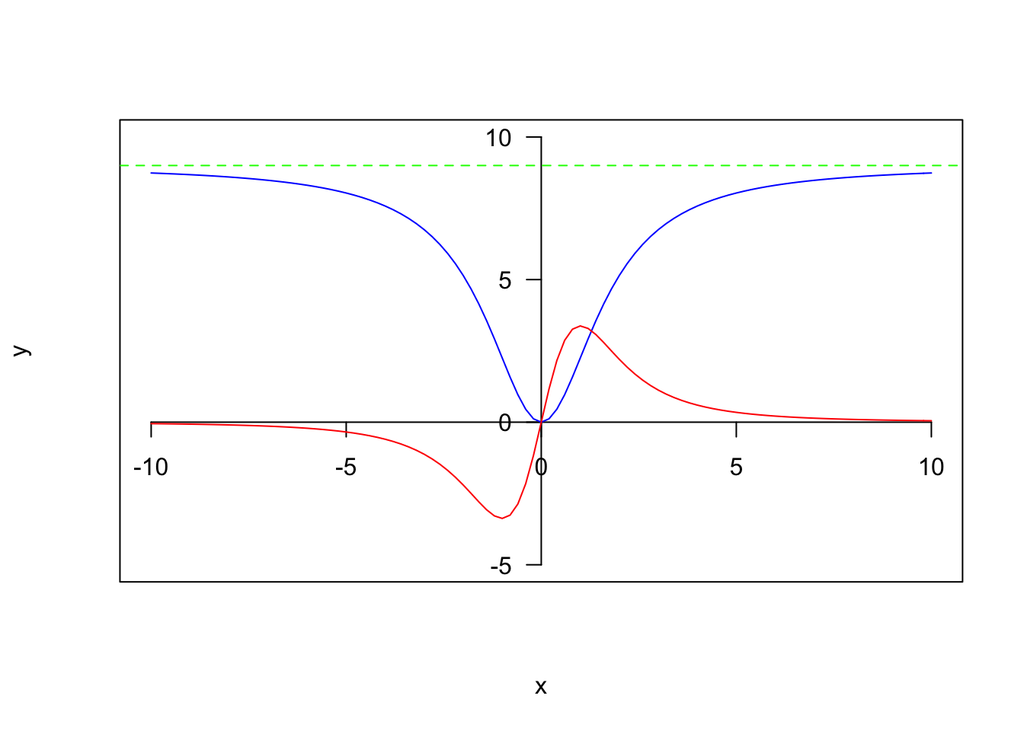

```r
plot( x = -10:10, y = -10:10, ylim = c(-5,10),
      type = "n", ylab = "y", xlab = "x",
      axes = FALSE)
box()
axis(1, pos=0, las = 1)
axis(2, pos=0, las = 1)
curve((9*x^2/(x^2+3)),
      col = "blue",
      add = TRUE)
abline(h = asintota, col="green", lty=2)
curve((54 * x/(x^4 + 6 * x^2 + 9)),
      col = "red",
      add = TRUE)
```

## Desafío 4.

Calcule $\displaystyle \int_0^1x^2dx$

```r
Integrate(x^2,x,0,1)
```

```
## expression(1/3)
```

Esta integral puede ser calculada también directamente en `R` con la función `integrate`. El gráfico que representa el área calculada es:

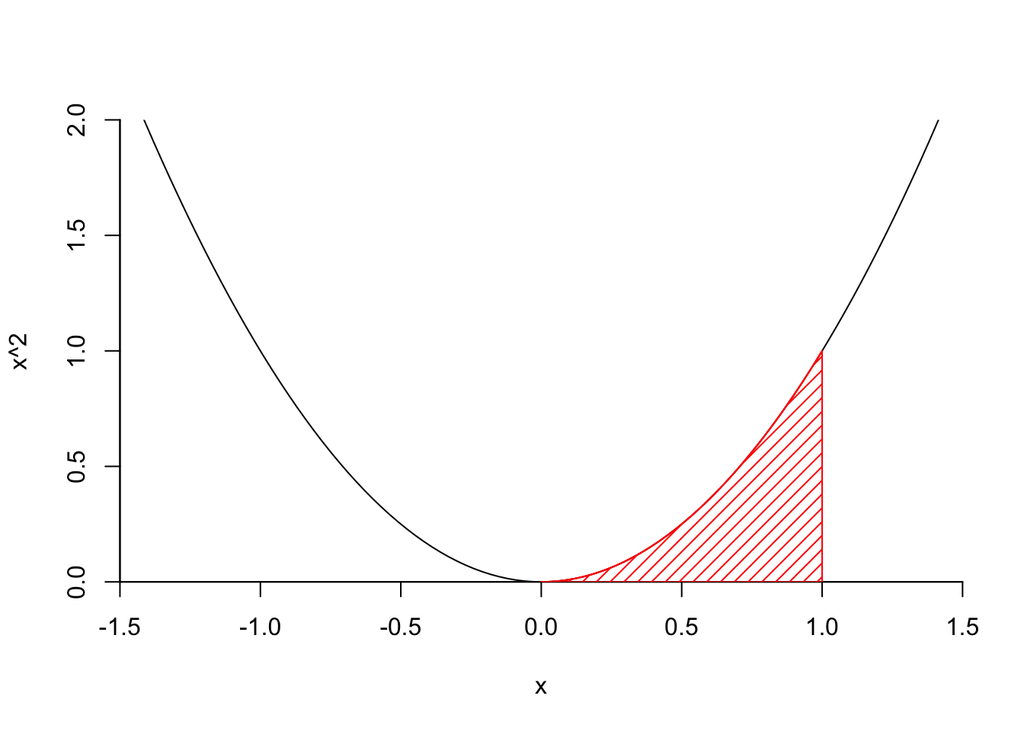

```r
curve(x^2,
      ylim = c(0,2), yaxs ="i",
      xlim = c(-1.5,1.5), xaxs = "i",
      bty = "L")
fun <- curve(x^2, from = 0, to = 1, add = T, col = "red")
polygon(x = c(fun$x, 1),
        y = c(fun$y, 0),
        density = 15,
        col = "red")
```

### Comentarios

- `yacmode()` es una forma de ocupar yacas directamente en la consola.
- Una buena explicación de cómo ocupar la función `polygon` [aqui](https://stackoverflow.com/questions/37472365/how-to-use-polygon-to-shade-below-a-probability-density-curve)
- Para volver el nivel de advertencias al default

```r
options(warn = 0)
```

**Cristóbal Lecaros C.**